# Practical Machine Learning- Final Project

Doron Fingold

2025-03-19

## Overview

We try to predict the manner in which exercise was executed. This is the `classe` variable in the training dataset. The dataset includes observation from accelerometers on the belt, forearm, arm, and dumbell of 6 participants. See more [here](https://web.archive.org/web/20200730234422/http://groupware.les.inf.puc-rio.br/har).We will try and find the best model for predicting `classe`.

## Data Sets

We are provided with 2 datasets.Training set with 19622 observations and 160 variables. And testing set with 20 observation and 160 variables which exclude `classe` replaced with `problem_id` for testing our prediction model.

```r
# URLs for data
training_url <- "https://d396qusza40orc.cloudfront.net/predmachlearn/pml-training.csv"
testing_url <- "https://d396qusza40orc.cloudfront.net/predmachlearn/pml-testing.csv"
# load data
pml.training <- read.csv(training_url)
pml.testing <- read.csv(testing_url)
# check dimensions
c(
    training_vars = ncol(pml.training),
    training_obs = nrow(pml.training),
    testing_vars = ncol(pml.testing),
    testing_obs = nrow(pml.testing)
)
```

```
## training_vars  training_obs  testing_vars   testing_obs
##           160         19622           160            20
```

# Explore and Feature selections

Reviewing the data and its sources we learn very little about what each variables means which makes it hard to know what is the right way to impute. We exclude variables with large missing variables and save as factors none numeric variables (`classe`, `user_name`, `window`).

```r
tidy_train <- pml.training
# remove columns with NA values since it is the majority of the observations
tidy_train <- tidy_train[, colSums(is.na(tidy_train)) == 0]
# removing variables with sparse records as well as variable X which seems to be a running number
exclude_Variables <- c(1, 5, 12:20, 43:48, 52:60, 74:82)
tidy_train <- tidy_train %>%
    select(-any_of(exclude_Variables))

# set as factors
tidy_train$classe <- as.factor(tidy_train$classe) # classe
tidy_train$user_name <- as.factor(tidy_train$user_name) # user_name
tidy_train <- tidy_train %>%
    mutate(new_window = if_else(new_window == "no", 0, 1)) # new_window

# remove the same columns from our testing set and replace "classe" with problem_id
tidy_test <- pml.testing %>%
    select(c(colnames(tidy_train[, -58]), "problem_id"))
# set factors as per training
tidy_test$user_name <- as.factor(tidy_test$user_name) # user_name
tidy_test <- tidy_test %>%
    mutate(new_window = if_else(new_window == "no", 0, 1)) # new_window
# check dimensions
c(
    training_vars = ncol(tidy_train),
    training_obs = nrow(tidy_train),
    testing_vars = ncol(tidy_test),
    testing_obs = nrow(tidy_test)
)
```

```
## training_vars  training_obs  testing_vars   testing_obs
##            58         19622            58            20
```

## Split Data to training, testing and validation

Our training dataset has 19,622 observations which is enough to split it into 3 sets. We put aside 20% of the records for validation at the end and split the remaining so that training has 60% and testing another 20%.

```r
# Partition data into build (train and test), and validation.
inBuild <- createDataPartition(y = tidy_train$classe, p = 0.8, list = FALSE)
validation <- tidy_train[-inBuild, ]
buildData <- tidy_train[inBuild, ]
# partition build data into training and testing sets.
inTrain <- createDataPartition(y = buildData$classe, p = 0.75, list = FALSE)
training <- buildData[inTrain, ]
testing <- buildData[-inTrain, ]

#check partitions
format_p <- function(portion, total){
    paste0(portion, " (",percent(portion / total), ")")
}
c(training = format_p(nrow(training), nrow(tidy_train)),
testing = format_p(nrow(testing) , nrow(tidy_train)) ,
validation = format_p(nrow(validation) , nrow(tidy_train)) ,
total = format_p(nrow(tidy_train), nrow(tidy_train)))
```

```
##       training        testing     validation          total
##  "11776 (60%)"   "3923 (20%)"   "3923 (20%)" "19622 (100%)"
```

## Fitting Different Models

### Linear Discriminant Analysis

```r
# train the model excluding categorical variables username and new_window
mod_lda <- train(classe ~ .,
                 data = training[, -c(1,4)],
                 method = "lda",
                 trainControl = trainControl(method = "cv", number = 3)
                 )
```

### Predict and Evaluate

```r
# predict the testing outcomes
p_lda <- predict(mod_lda, testing)
```

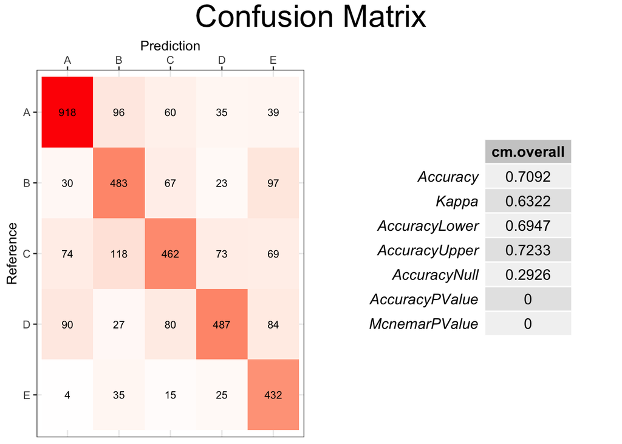

```r
# compare prediction with test outcomes
cm_lda <- confusionMatrix(testing$classe, p_lda)
plot_cm(cm_lda)
```

We observe accuracy of 71%.

## Random Forests

Random Forest algorithms offer several advantages, including high accuracy, robustness to outliers and missing data, versatility for both classification and regression, and the ability to easily determine feature importance. We will need to use parallel processing for this one.

```r
# register parallel processing
cluster <- makeCluster(detectCores() - 1) # convention to leave 1 core for OS
registerDoParallel(cluster)
fit_control <- trainControl(method = "cv", number = 3, allowParallel = TRUE)
# train model
mod_rf <- train(classe ~ ., data = training, method = "rf", trControl = fit_control)
# de-register parallel processing
stopCluster(cluster)
registerDoSEQ()
```

### Predict and Evaluate

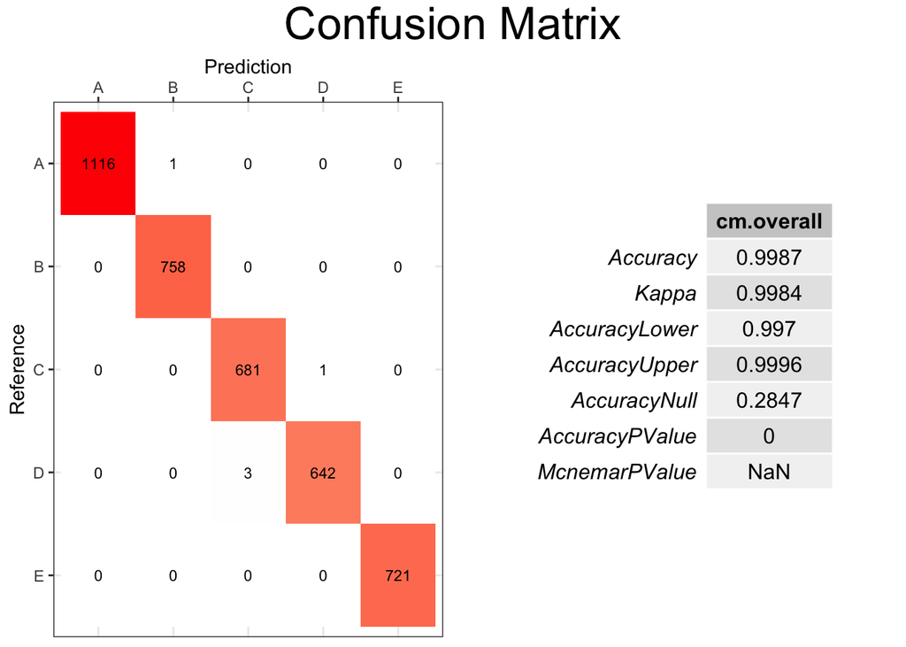

```r
p_rf <- predict(mod_rf, testing)
cm_rf <- confusionMatrix(testing$classe, p_rf)
plot_cm(cm_rf)
```

Amazingly we observe accuracy of 99.9%!

## Estimating Out of Sample Error

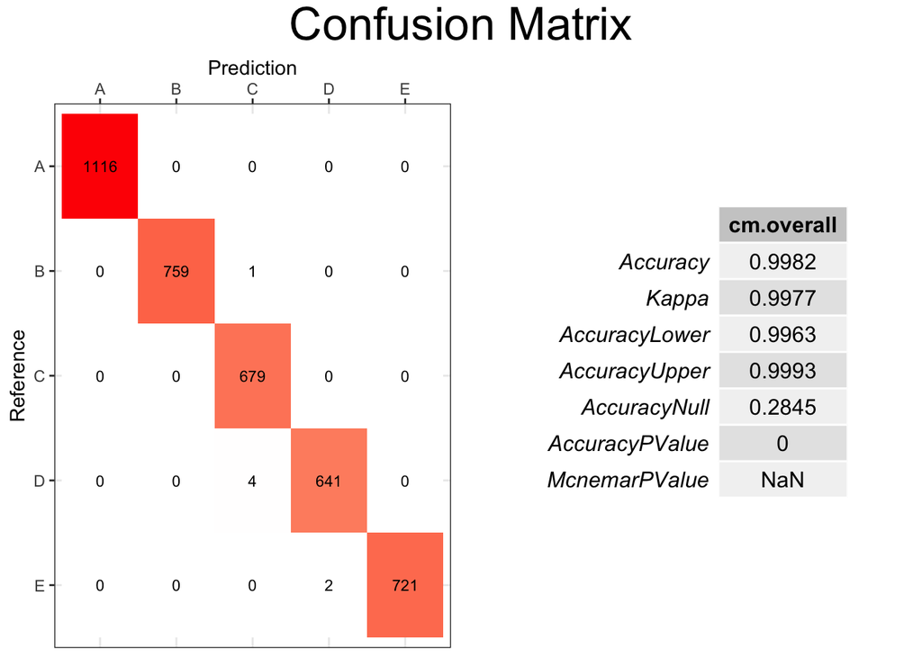

```r
p_rf_v <- predict(mod_rf, validation)
cm_rf_v <- confusionMatrix(validation$classe, p_rf_v)

plot_cm(cm_rf_v)
```

Accuracy is expected to be a little lower however it is still an impressive 99.8%.

## Conclusion

Machine learning using Random Forest has great success at predicting the manner in which an exercise is preformed based on data collected from a variety of accelerometers. Some limitation include interpretability of the predictions.